# Bayesian VAR with bvartools

Bruce Hartman

University of St. Francis

2026-03-18

Abstract

We work some Bayesian VAR applications with the `bvartools` package, from Mohr, 2024. This package gives you a lot more options than the `vars` package, and can produce the same results.

# Introduction

We are going to reproduce and check a simple Vector Autocorrelation Regression (VAR) model using the `bvartools` package and an example from (Mohr, 2024). This package gives you more flexibility than the `vars` package, and you can get the same results by making the Bayesian part— the prior distribution of variables— independent and not correlated.

# Packages

Load `bvartools` and the `mbadtools` package and then the standard packages using the `lib_packages()` function. Other packages needed are for special uses.

```r
library(bvartools)
library(vars)
library(forecast) # nice plots
# load github packages
library(mbadtools)
# list of packages to install
# load packages to the notebook
lib_packages(mbad_standard_packages, quiet=TRUE)
```

```
Loading MBAD packages:
 tidyverse ggfortify GGally skimr broom gt patchwork car yardstick ggResidpanel ggh4x
```

# Data

The data set `e1` from Lütkepohl (2006) is used. It contains data on West German fixed investment, disposable income and consumption expenditures in billions of DM from 1960Q1 to 1982Q4. Like in the textbook only the first 73 observations of the log-differenced series are used.

```r
# Load data
data("e1")
e1 %>% glimpse
```

```
 Time-Series [1:92, 1:3] from 1960 to 1983: 180 179 185 192 211 202 207 214 231 229 ...
 - attr(*, "dimnames")=List of 2
  ..$ : NULL
  ..$ : chr [1:3] "invest" "income" "cons"
```

# Data Description

Describe the data using simple display, or `skim`. It is a matrix of three `ts` timeseries.

```r
e1 %>% class
```

```
[1] "mts"    "ts"     "matrix"
```

```r
e1 %>% skim
```

```
── Data Summary ────────────────────────
                           Values
Name                       Piped data
Number of rows             92
Number of columns          3
_______________________
Column type frequency:
  numeric                  3
________________________
Group variables            None
```

|  | skim_variable | n_missing | complete_rate | mean | sd | p0 | p25 | p50 | p75 | p100 | hist |
| --- | --- | --- | --- | --- | --- | --- | --- | --- | --- | --- | --- |
| 1 | invest | 0 | 1 | 471.913 | 210.7467 | 179 | 288.25 | 495.0 | 598.50 | 870 | ▇▂▆▂▃ |
| 2 | income | 0 | 1 | 1355.087 | 698.9288 | 451 | 760.00 | 1194.5 | 1918.25 | 2651 | ▇▃▃▃▃ |
| 3 | cons | 0 | 1 | 1166.674 | 590.9236 | 415 | 664.25 | 1023.5 | 1658.75 | 2271 | ▇▃▃▃▃ |

# Research Problem

We demonstrate use of the `bvartools` package functions to produce a VAR model on the `e1` dataset. We then compare the result with a similar model processed with `vars` to demonstrate the same results.`bvartools` is much more flexible and allows Bayesian versions of VAR.

# Data Wrangling

We work with first differences of the logged timeseries.

```r
e1d <- diff(log(e1)) * 100
```

Reduce number of oberservations, by limiting to last quarter of 1978.

```r
e1d <- window(e1d, end = c(1978, 4))
```

# Data Visualization

Graphic displays of data.

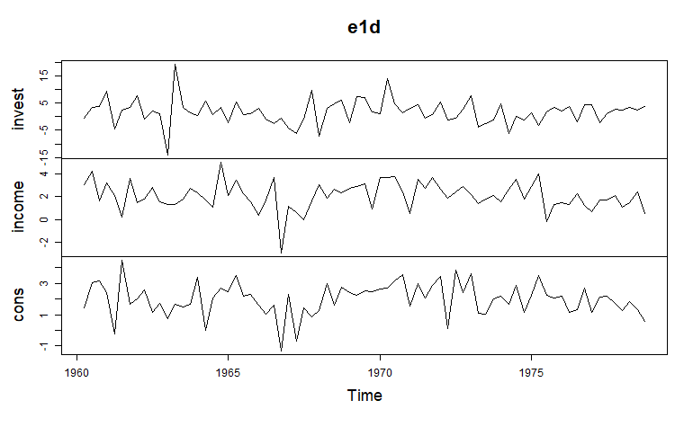

```r
plot(e1d)
```

A better ggplot way to see the time series with correlograms:

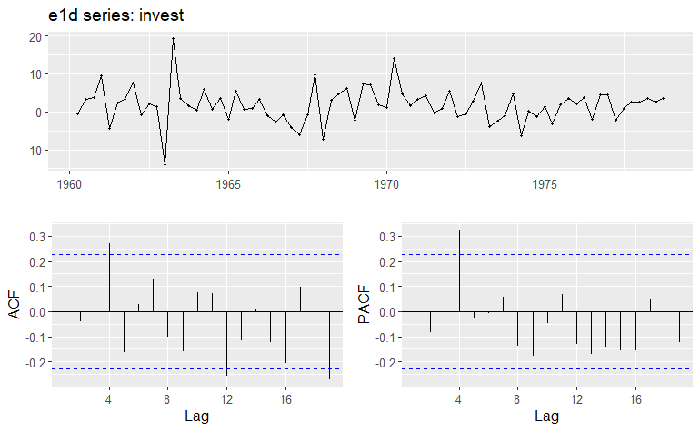

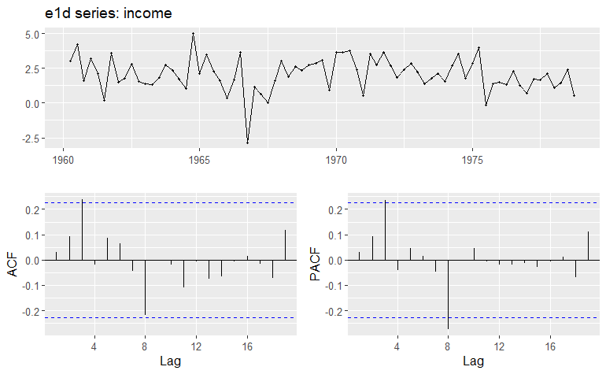

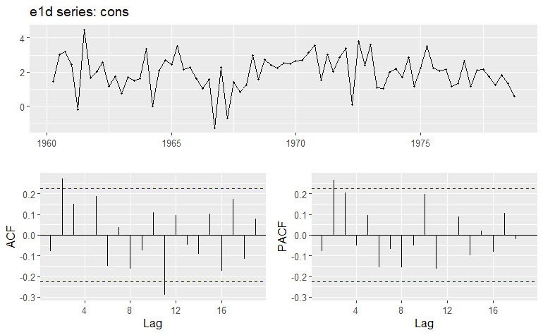

```r
# grab names of series
names = attr(e1d, "dimnames")[[2]]
# time series displays with acf/pacf
for (i in 1:3) e1d[,i] %>%
  forecast::ggtsdisplay(main = str_c("e1d series: ", names[i]))
```

All three series are pretty stationary.

# Create models

```r
model <- gen_var(e1d, p = 2, deterministic = "const",
                 iterations = 100, burnin = 10)
```

```r
model %>% glimpse
```

```
List of 2
 $ data :List of 4
  ..$ Y   : Time-Series [1:73, 1:3] from 1961 to 1979: 3.71 9.44 -4.36 2.45 3.33 ...
  .. ..- attr(*, "dimnames")=List of 2
  ..$ Z   : Time-Series [1:73, 1:7] from 1961 to 1979: 3.3 3.71 9.44 -4.36 2.45 ...
  .. ..- attr(*, "dimnames")=List of 2
  ..$ SUR : num [1:219, 1:21] 3.3 0 0 3.71 0 ...
  ..$ TEST: NULL
 $ model:List of 8
  ..$ type         : chr "VAR"
  ..$ endogen      :List of 2
  .. ..$ variables: chr [1:3] "invest" "income" "cons"
  .. ..$ lags     : num 2
  ..$ deterministic: chr "const"
  ..$ structural   : logi FALSE
  ..$ tvp          : logi FALSE
  ..$ sv           : logi FALSE
  ..$ iterations   : num 100
  ..$ burnin       : num 10
 - attr(*, "class")= chr [1:2] "bvarmodel" "list"
```

## Add priors

```r
model_with_priors <- add_priors(model,
                                coef = list(v_i = 0, v_i_det = 0),
                                sigma = list(df = 1, scale = .0001))
model_with_priors %>% glimpse
```

```
List of 4
 $ data   :List of 4
  ..$ Y   : Time-Series [1:73, 1:3] from 1961 to 1979: 3.71 9.44 -4.36 2.45 3.33 ...
  .. ..- attr(*, "dimnames")=List of 2
  ..$ Z   : Time-Series [1:73, 1:7] from 1961 to 1979: 3.3 3.71 9.44 -4.36 2.45 ...
  .. ..- attr(*, "dimnames")=List of 2
  ..$ SUR : num [1:219, 1:21] 3.3 0 0 3.71 0 ...
  ..$ TEST: NULL
 $ model  :List of 8
  ..$ type         : chr "VAR"
  ..$ endogen      :List of 2
  .. ..$ variables: chr [1:3] "invest" "income" "cons"
  .. ..$ lags     : num 2
  ..$ deterministic: chr "const"
  ..$ structural   : logi FALSE
  ..$ tvp          : logi FALSE
  ..$ sv           : logi FALSE
  ..$ iterations   : num 100
  ..$ burnin       : num 10
 $ priors :List of 2
  ..$ coefficients:List of 2
  .. ..$ mu : num [1:21, 1] 0 0 0 0 0 0 0 0 0 0 ...
  .. ..$ v_i: num [1:21, 1:21] 0 0 0 0 0 0 0 0 0 0 ...
  ..$ sigma       :List of 3
  .. ..$ type : chr "wishart"
  .. ..$ df   : num 1
  .. ..$ scale: num [1:3, 1:3] 1e-04 0e+00 0e+00 0e+00 1e-04 0e+00 0e+00 0e+00 1e-04
 $ initial:List of 2
  ..$ coefficients:List of 1
  .. ..$ draw: num [1:21, 1] -0.31963 0.04393 -0.00242 0.14599 -0.15273 ...
  ..$ sigma       :List of 1
  .. ..$ sigma_i: num [1:3, 1:3] 0.0512 0 0 0 0.7943 ...
  .. .. ..- attr(*, "dimnames")=List of 2
 - attr(*, "class")= chr [1:2] "bvarmodel" "list"
```

## Estimate model

```r
bvar_est <- draw_posterior(model_with_priors)
```

```
Estimating model...
```

```r
# bvar_est %>% glimpse
bvar_est %>% summary
```

```
Bayesian VAR model with p = 2

Model:

y ~ invest.01 + income.01 + cons.01 + invest.02 + income.02 + cons.02 + const

Variable: invest

             Mean     SD Naive SD Time-series SD    2.5%     50%    97.5%
invest.01 -0.2994 0.1325  0.01325        0.01325 -0.5461 -0.2956 -0.02796
income.01  0.2240 0.5460  0.05460        0.04641 -0.7601  0.1383  1.20149
cons.01    0.9259 0.6986  0.06986        0.06986 -0.5416  0.9807  2.11937
invest.02 -0.1823 0.1260  0.01260        0.01260 -0.3993 -0.1931  0.04596
income.02  0.1669 0.5656  0.05656        0.05656 -1.0208  0.2018  1.01796
cons.02    0.9206 0.7523  0.07523        0.07523 -0.4482  0.8813  2.36652
const     -1.8708 1.9179  0.19179        0.19179 -5.1711 -1.9583  1.99326

Variable: income

              Mean      SD Naive SD Time-series SD      2.5%      50%   97.5%
invest.01  0.04617 0.02898 0.002898       0.002898  0.001570  0.04569 0.09895
income.01 -0.14767 0.15002 0.015002       0.015002 -0.476293 -0.13028 0.08616
cons.01    0.26912 0.19102 0.019102       0.019102 -0.113364  0.27840 0.59316
invest.02  0.04917 0.03131 0.003131       0.002532 -0.007652  0.05227 0.10656
income.02  0.02077 0.13998 0.013998       0.013998 -0.274598  0.01768 0.24309
cons.02   -0.04002 0.18065 0.018065       0.018065 -0.359973 -0.03532 0.29213
const      1.65459 0.48173 0.048173       0.048173  0.790213  1.65574 2.59013

Variable: cons

                Mean      SD Naive SD Time-series SD     2.5%       50%     97.5%
invest.01  7.105e-05 0.02527 0.002527       0.001755 -0.04107 -0.002492  0.049163
income.01  2.340e-01 0.10413 0.010413       0.010413  0.01712  0.237191  0.433118
cons.01   -2.801e-01 0.13315 0.013315       0.008349 -0.50575 -0.277768 -0.001653
invest.02  3.084e-02 0.02726 0.002726       0.002484 -0.01739  0.029968  0.085438
income.02  3.657e-01 0.12131 0.012131       0.009488  0.13766  0.354334  0.593993
cons.02   -4.802e-02 0.13714 0.013714       0.016636 -0.32280 -0.058170  0.233991
const      1.328e+00 0.38177 0.038177       0.044998  0.56262  1.371042  1.985788

Variance-covariance matrix:

                 Mean     SD Naive SD Time-series SD    2.5%     50%  97.5%
invest_invest 21.9862 3.7782  0.37782        0.47306 15.9690 21.7476 30.232
invest_income  0.7792 0.8108  0.08108        0.12358 -0.6216  0.7362  2.114
invest_cons    1.2823 0.5600  0.05600        0.06585  0.3464  1.2500  2.394
income_invest  0.7792 0.8108  0.08108        0.12358 -0.6216  0.7362  2.114
income_income  1.4520 0.3156  0.03156        0.03156  1.0529  1.4205  1.905
income_cons    0.6461 0.2110  0.02110        0.02110  0.3550  0.6075  1.117
cons_invest    1.2823 0.5600  0.05600        0.06585  0.3464  1.2500  2.394
cons_income    0.6461 0.2110  0.02110        0.02110  0.3550  0.6075  1.117
cons_cons      0.9420 0.1996  0.01996        0.01996  0.6787  0.9078  1.419
```

## IRF Plots

`bvartools` only lets you plot one response at a time. And you have to convert the model output to the `vars::varirf` format using `mbadtools::bvarirf_to_varirf()`.

Impulse `invest`:

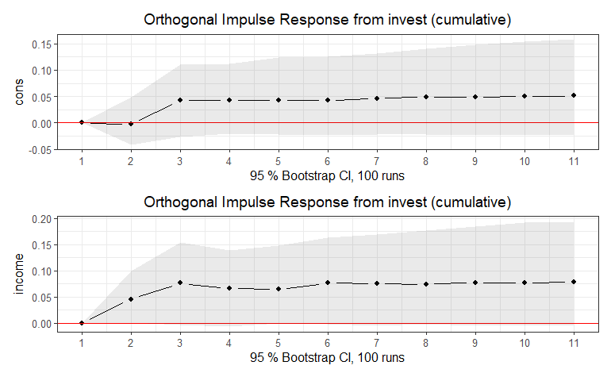

```r
list(
  bvartools::irf(bvar_est, impulse = "invest", response = "cons",
                          cumulative=TRUE,
                          n.ahead=10) %>%
    bvarirf_to_varirf("invest","cons", cumulative=TRUE) %>%
    ggvar_irf(),
  bvartools::irf(bvar_est, impulse = "invest", response = "income",
                          cumulative=TRUE,
                          n.ahead=10) %>%
    bvarirf_to_varirf("invest","income", cumulative=TRUE) %>%
    ggvar_irf()
) %>% wrap_plots(nrow=2)
```

Impulse `income`:

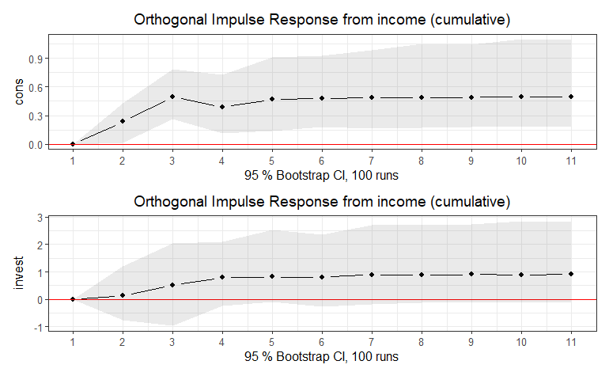

```r
list(
  bvartools::irf(bvar_est, impulse = "income", response = "cons",
                          cumulative=TRUE,
                          n.ahead=10) %>%
    bvarirf_to_varirf("income","cons", cumulative=TRUE) %>%
    ggvar_irf(),
  bvartools::irf(bvar_est, impulse = "income", response = "invest",
                          cumulative=TRUE,
                          n.ahead=10) %>%
    bvarirf_to_varirf("income","invest", cumulative=TRUE) %>%
    ggvar_irf()
) %>% wrap_plots(nrow=2)
```

Impulse `cons`:

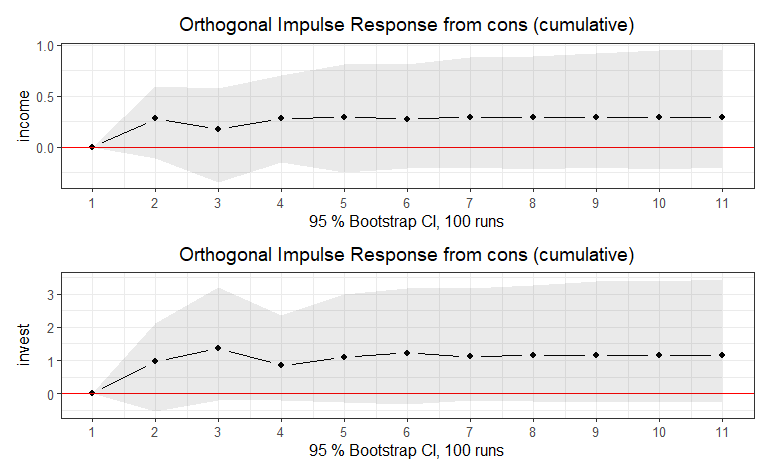

```r
list(
  bvartools::irf(bvar_est, impulse = "cons", response = "income",
                          cumulative=TRUE,
                          n.ahead=10) %>%
    bvarirf_to_varirf("cons","income", cumulative=TRUE) %>%
    ggvar_irf(),
  bvartools::irf(bvar_est, impulse = "cons", response = "invest",
                          cumulative=TRUE,
                          n.ahead=10) %>%
    bvarirf_to_varirf("cons","invest", cumulative=TRUE) %>%
    ggvar_irf()
) %>% wrap_plots(nrow=2)
```

We see the long term effects of an impulse to any of the three variables.

## FEVD Plots

Forecast error variance decomposition is usually visualized in a plot. The standard `bvartools` way is to produce an object of class `bvarfevd` with the function `fevd.bvar()`, and then plot it. To compute it, specify which response estimate to use with the ‘response’ parameter. The result is just 3 time series. To keep consistent with the forecast length below, we set ‘n.ahead=10’

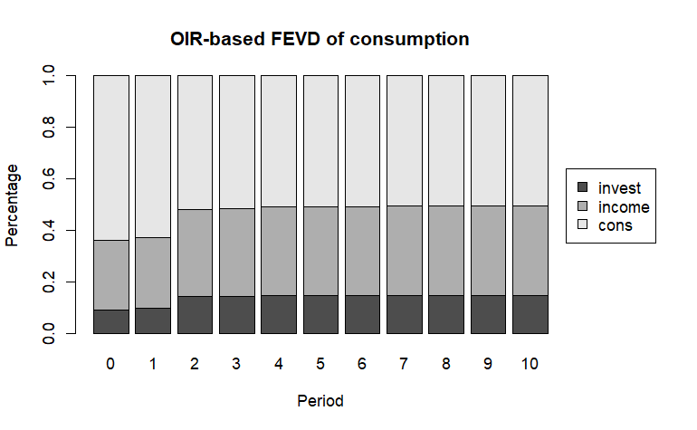

```r
vd = fevd(bvar_est, response="cons", n.ahead=10) # this is `fevd.bvar()`
plot(vd, main="OIR-based FEVD of consumption")
```

With the `mbadtools::ggvar_fevdplot()` function we can create plots for all the responses at once. They are stored in a list, any or all of which which can be plotted using `patchwork` logic. This function also creates the `bvartools::bvarfevd` output object so we must specify the `fevd` input parameters for it. See the [documentation for `bvartools::fevd.bvar`.](https://www.rdocumentation.org/packages/bvartools/topics/fevd.bvar)

All responses at once:

[figure not shown]

```r
bvar_est %>%
  ggvar_fevdplot(bvar_est, type="oir", n.ahead=10) %>%
  wrap_plots(ncol=2, guides="collect")
```

A single response, `cons`:

[figure not shown]

```r
P = bvar_est %>%
  ggvar_fevdplot(bvar_est, type="oir", n.ahead=10)
P[["cons"]]
```

## Forecasts

Predict 10 periods ahead, with confidence bands. Use the `mbadtools::ggvar_forecastplot()` function directly on the predictions class `bvarprd` object.

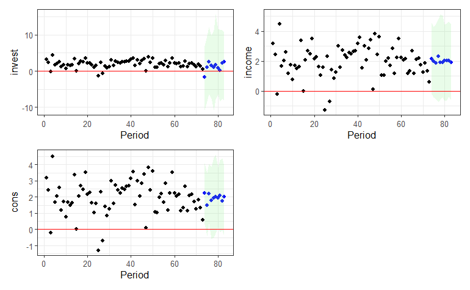

```r
bvar_pred <- predict(bvar_est, n.ahead = 10, new_d = rep(1, 10))
# bvar_pred %>% glimpse
# plot(bvar_pred)
bvar_pred %>% ggvar_forecastplot() %>%
  wrap_plots(design="12\n3#")
```

# VAR Analysis

We are doing the VAR analysis with the `vars::VAR` function for comparison. View [the `vars` documentation](https://www.rdocumentation.org/packages/vars/versions/1.6-1) for details.

## `vars` Model

```r
modelV = VAR(e1d, p=2)
modelV %>% summary
```

```
VAR Estimation Results:
=========================
Endogenous variables: invest, income, cons
Deterministic variables: const
Sample size: 73
Log Likelihood: -402.225
Roots of the characteristic polynomial:
0.5705 0.5513 0.5513 0.4917 0.4917 0.3712
Call:
VAR(y = e1d, p = 2)


Estimation results for equation invest:
=======================================
invest = invest.l1 + income.l1 + cons.l1 + invest.l2 + income.l2 + cons.l2 + const

          Estimate Std. Error t value Pr(>|t|)
invest.l1  -0.3196     0.1255  -2.548   0.0132 *
income.l1   0.1460     0.5457   0.268   0.7899
cons.l1     0.9612     0.6643   1.447   0.1526
invest.l2  -0.1606     0.1249  -1.285   0.2032
income.l2   0.1146     0.5346   0.214   0.8309
cons.l2     0.9344     0.6651   1.405   0.1647
const      -1.6722     1.7226  -0.971   0.3352
---
Signif. codes:  0 ‘***’ 0.001 ‘**’ 0.01 ‘*’ 0.05 ‘.’ 0.1 ‘ ’ 1


Residual standard error: 4.615 on 66 degrees of freedom
Multiple R-Squared: 0.1286, Adjusted R-squared: 0.04934
F-statistic: 1.623 on 6 and 66 DF,  p-value: 0.1547


Estimation results for equation income:
=======================================
income = invest.l1 + income.l1 + cons.l1 + invest.l2 + income.l2 + cons.l2 + const

          Estimate Std. Error t value Pr(>|t|)
invest.l1  0.04393    0.03186   1.379 0.172578
income.l1 -0.15273    0.13857  -1.102 0.274378
```

[output cut: 32 more lines]

```
F-statistic: 3.692 on 6 and 66 DF,  p-value: 0.003184



Covariance matrix of residuals:
        invest income   cons
invest 21.2963 0.7162 1.2324
income  0.7162 1.3734 0.6146
cons    1.2324 0.6146 0.8920

Correlation matrix of residuals:
       invest income   cons
invest 1.0000 0.1324 0.2828
income 0.1324 1.0000 0.5553
cons   0.2828 0.5553 1.0000
```

## Covariances and testing

```r
# covariance matrices
V.covariance = (modelV %>% summary)[["covres"]]
B.covariance = (bvar_est %>% summary)[["sigma"]]$means
#Compare using `covequal::test_covequal()`
if(interactive()) cat("\nEqual covariance test `covequal::test_covequal()`\n")
```

```
Equal covariance test `covequal::test_covequal()`
```

```r
covequal::test_covequal(V.covariance,B.covariance)
```

```
$test_statistic
[1] 0.9486163

$pvalue
[1] 0.8313428
```

```r
#Compare using `mvhtests::equal.cov()`:
if(interactive()) cat("\nEqual covariance test `mvhtests::equal.cov()`\n")
```

```
Equal covariance test `mvhtests::equal.cov()`
```

```r
mvhtests::equal.cov(V.covariance,B.covariance)
```

```
        test           df      p-value     critical
1.188526e+02 6.000000e+00 2.838052e-23 1.259159e+01
```

```r
# prep for other `mvhtests` tests
combined_data=rbind(V.covariance,B.covariance)
ina = c(rep(1, nrow(V.covariance)), rep(2, nrow(B.covariance)))
if(interactive()) cat("\nM test `mvhtests::Mtest()`\n")
```

```
M test `mvhtests::Mtest()`
```

```r
mvhtests::Mtest.cov(combined_data, ina = ina)
```

```
     M.test     p-value          df    critical
15.44981592  0.01703236  6.00000000 12.59158724
```

```r
if(interactive()) cat("\nLikelihood test `mvhtests::likel.cov()`\n")
```

```
Likelihood test `mvhtests::likel.cov()`
```

```r
mvhtests::likel.cov(combined_data, ina = ina)
```

```
        test      p-value           df     critical
1.238921e+02 2.478497e-24 6.000000e+00 1.259159e+01
```

## Residual Tests

```r
modelV %>% serial.test(lags.pt = 10, type = "PT.asymptotic")
```

```
    Portmanteau Test (asymptotic)

data:  Residuals of VAR object .
Chi-squared = 56.812, df = 72, p-value = 0.9051
```

```r
modelV %>% normality.test()
```

```
$JB

    JB-Test (multivariate)

data:  Residuals of VAR object .
Chi-squared = 21.963, df = 6, p-value = 0.001229


$Skewness

    Skewness only (multivariate)

data:  Residuals of VAR object .
Chi-squared = 4.2615, df = 3, p-value = 0.2346


$Kurtosis

    Kurtosis only (multivariate)

data:  Residuals of VAR object .
Chi-squared = 17.702, df = 3, p-value = 0.0005067
```

```r
modelV %>% arch.test(lags.multi = 5)
```

```
    ARCH (multivariate)

data:  Residuals of VAR object .
Chi-squared = 164.71, df = 180, p-value = 0.7866
```

## Stability Test

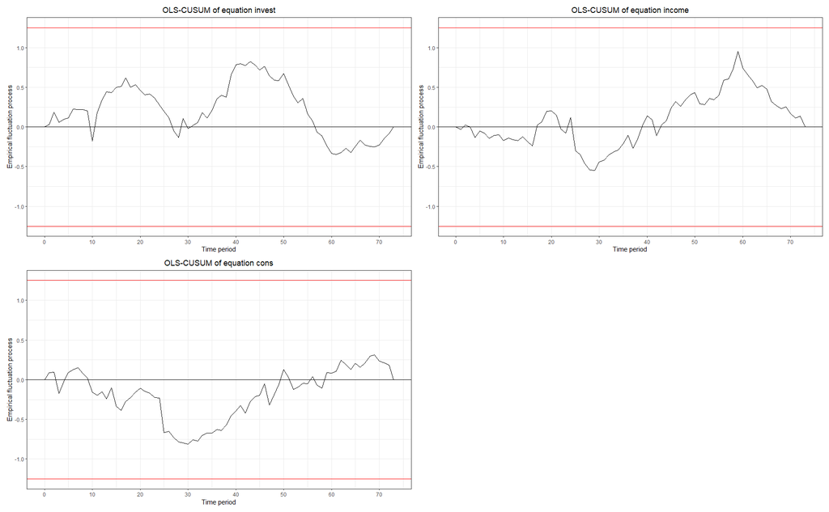

```r
stab_test <- stability(modelV, type = "OLS-CUSUM")
# stab_test %>% plot() # defaults to 1.2516 for limits
# stab_test %>% plot(ylim=c(-1.2516, 1.2516 )) # shows what the limits are, 1.2516
stab_test %>% ggvar_plot_stability() %>% wrap_plots(design="12\n3#")
```

## IRF plots

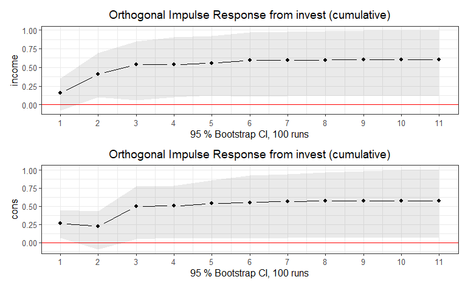

```r
list(
  modelV %>% vars::irf(impulse="invest", response=c("income"),
                      cumulative=TRUE) %>% ggvar_irf(),
  modelV %>% vars::irf(impulse="invest", response=c("cons"),
                      cumulative=TRUE) %>% ggvar_irf()
) %>% wrap_plots(nrow=2)
```

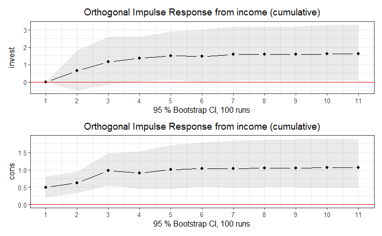

```r
list(
  modelV %>% vars::irf(impulse="income", response=c("invest"),
                      cumulative=TRUE) %>% ggvar_irf(),
  modelV %>% vars::irf(impulse="income", response=c("cons"),
                      cumulative=TRUE) %>% ggvar_irf()
) %>% wrap_plots(nrow=2)
```

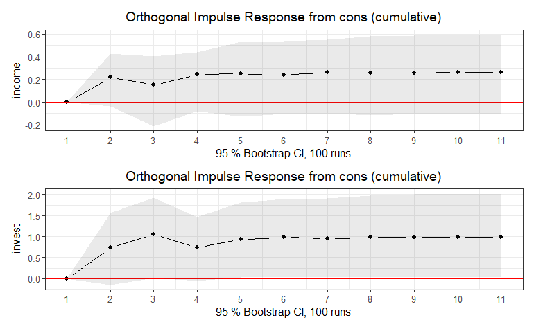

```r
list(
  modelV %>% vars::irf(impulse="cons", response=c("income"),
                      cumulative=TRUE) %>% ggvar_irf(),
  modelV %>% vars::irf(impulse="cons", response=c("invest"),
                      cumulative=TRUE) %>% ggvar_irf()
) %>% wrap_plots(nrow=2)
```

# Conclusion

The `bvartools` package is much more flexible and permits different modeling techniques to be used. It’s designed for academics and people who need to have modeling flexibility.

# References

1. Mohr, Franz X. (2024) Introduction to `bvartools`. Package vignette. (https://cran.r-project.org/web/packages/bvartools/vignettes/bvartools.html)
2. Lütkepohl, H. (2006). New introduction to multiple time series analysis (2nd ed.). Berlin: Springer.
3. Chan, J., Koop, G., Poirier, D. J., & Tobias, J. L. (2019). Bayesian Econometric Methods (2nd ed.). Cambridge: University Press.